# Chap3_04-19-2019_Kazu

Kazu

4/19/2019

# Chapter 4 Geocentric Models

```r
## R code 4.1
pos <- replicate( 1000 , sum( runif(16,-1,1) ) )

## R code 4.2
prod( 1 + runif(12,0,0.1) )
```

```
## [1] 2.323495
```

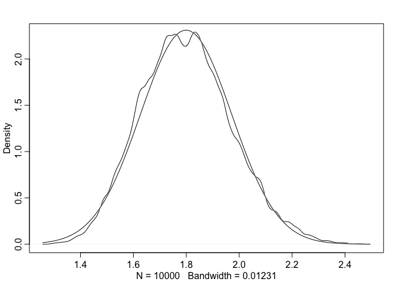

```r
## R code 4.3
growth <- replicate( 10000 , prod( 1 + runif(12,0,0.1) ) )
dens( growth , norm.comp=TRUE )
```

```r
## R code 4.4
big <- replicate( 10000 , prod( 1 + runif(12,0,0.5) ) )
small <- replicate( 10000 , prod( 1 + runif(12,0,0.01) ) )

## R code 4.5
log.big <- replicate( 10000 , log(prod(1 + runif(12,0,0.5))) )

## R code 4.6
w <- 6; n <- 9;
p_grid <- seq(from=0,to=1,length.out=100)
posterior <- dbinom(w,n,p_grid)*dunif(p_grid,0,1)
posterior <- posterior/sum(posterior)
```

4.3. A Gaussian model of height

```r
## R code 4.7
library(rethinking)
data(Howell1)
d <- Howell1

## R code 4.8
str( d )
```

```
## 'data.frame':    544 obs. of  4 variables:
##  $ height: num  152 140 137 157 145 ...
##  $ weight: num  47.8 36.5 31.9 53 41.3 ...
##  $ age   : num  63 63 65 41 51 35 32 27 19 54 ...
##  $ male  : int  1 0 0 1 0 1 0 1 0 1 ...
```

```r
## R code 4.9 (new in book)
precis(d)
```

```
##               mean         sd      5.5%     94.5%     histogram
## height 138.2635963 27.6024476 81.108550 165.73500 ▁▁▁▁▁▁▁▂▁▇▇▅▁
## weight  35.6106176 14.7191782  9.360721  54.50289 ▁▂▃▂▂▂▂▅▇▇▃▂▁
## age     29.3443934 20.7468882  1.000000  66.13500     ▇▅▅▃▅▂▂▁▁
## male     0.4724265  0.4996986  0.000000   1.00000    ▇▁▁▁▁▁▁▁▁▇
```

```r
## R code 4.10
d$height
```

[output not shown]

[output cut: 63 more lines]

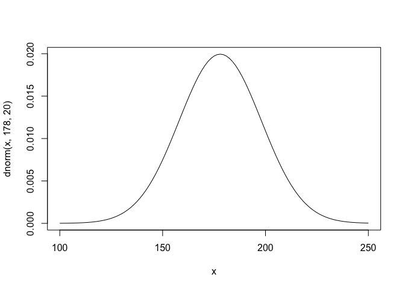

```r
## R code 4.11
d2 <- d[ d$age >= 18 , ] # All we want for now are heights of adults in the sample. The reason to filter out non- adults for now is that height is strongly correlated with age, before adulthood.

## R code 4.12 (prior)
curve( dnorm( x , 178 , 20 ) , from=100 , to=250 )
```

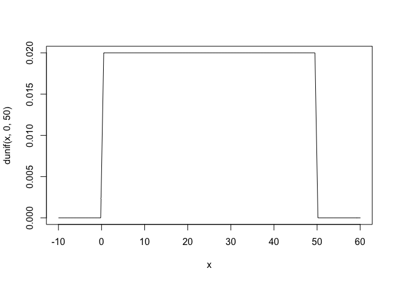

```r
## R code 4.13 (prior, sigma)
curve( dunif( x , 0 , 50 ) , from=-10 , to=60 )
```

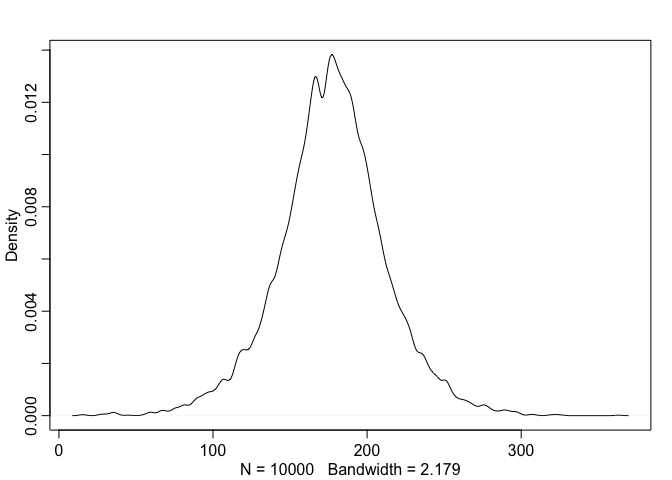

```r
## R code 4.14 (prior predictive simulation)
sample_mu <- rnorm( 1e4 , 178 , 20 )
sample_sigma <- runif( 1e4 , 0 , 50 )
prior_h <- rnorm( 1e4 , sample_mu , sample_sigma )
dens( prior_h )
```

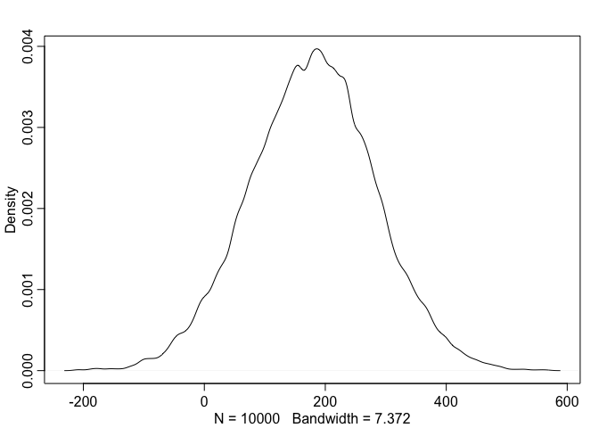

```r
## R code 4.15
sample_mu <- rnorm( 1e4 , 178 , 100 )
prior_h <- rnorm( 1e4 , sample_mu , sample_sigma )
dens( prior_h )
```

## 4.3.3 Grid approximation of the posterior distribution

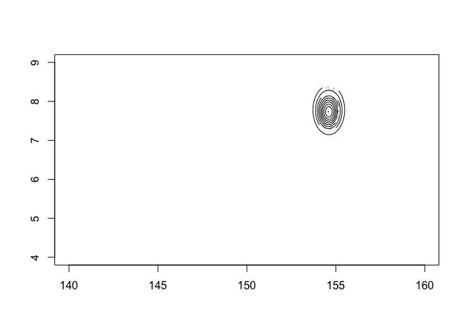

```r
## R code 4.16
mu.list <- seq( from=140, to=160 , length.out=200 )
sigma.list <- seq( from=4 , to=9 , length.out=200 )
# base::expand.grid below is super useful function to make data.frame!
post <- expand.grid( mu=mu.list , sigma=sigma.list ) #
post$LL <- sapply( 1:nrow(post) , function(i) sum( dnorm(
                d2$height ,
                mean=post$mu[i] ,
                sd=post$sigma[i] ,
                log=TRUE ) ) )
post$prod <- post$LL + dnorm( post$mu , 178 , 20 , TRUE ) +
    dunif( post$sigma , 0 , 50 , TRUE )
post$prob <- exp( post$prod - max(post$prod) )

## R code 4.17
contour_xyz( post$mu , post$sigma , post$prob )
```

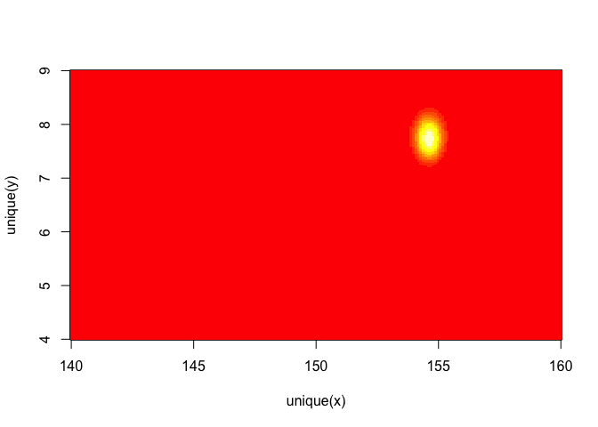

```r
## R code 4.18
image_xyz( post$mu , post$sigma , post$prob )
```

4.3.4 Sampling from the posterior

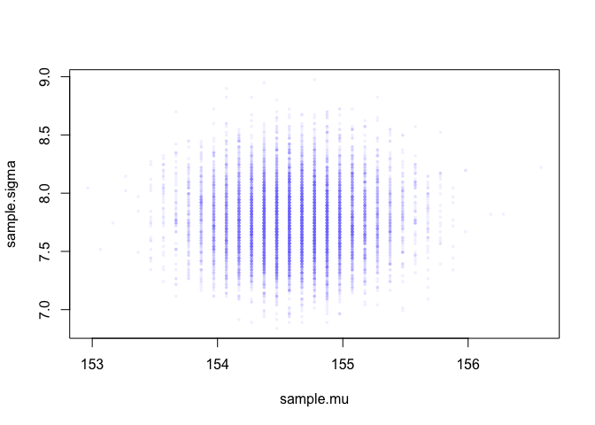

```r
## R code 4.17
sample.rows <- sample( 1:nrow(post) , size=1e4 , replace=TRUE ,
    prob=post$prob )
sample.mu <- post$mu[ sample.rows ]
sample.sigma <- post$sigma[ sample.rows ]

## R code 4.18
plot( sample.mu , sample.sigma , cex=0.5 , pch=16 , col=col.alpha(rangi2,0.1) )
```

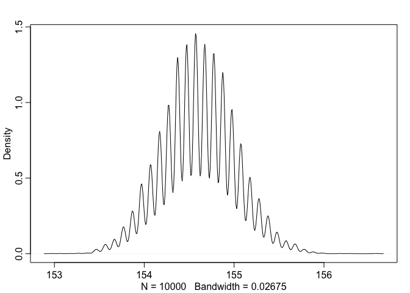

```r
## R code 4.20
dens( sample.mu )
```

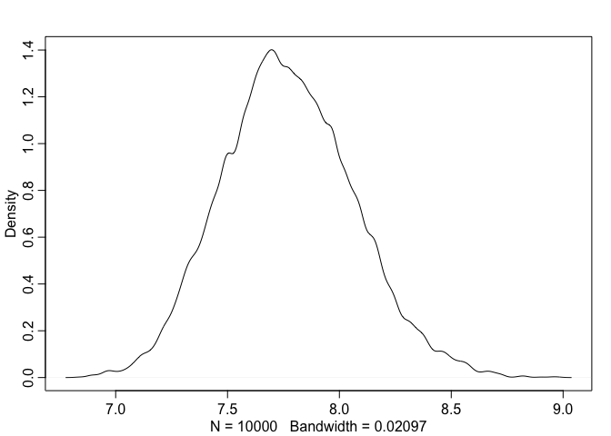

```r
dens( sample.sigma )
```

```r
## R code 4.22
HPDI( sample.mu )
```

```
##    |0.89    0.89|
## 153.8693 155.1759
```

```r
HPDI( sample.sigma )
```

```
##    |0.89    0.89|
## 7.266332 8.195980
```

Overthinking: Sample size and the normality of σ’s posterior.

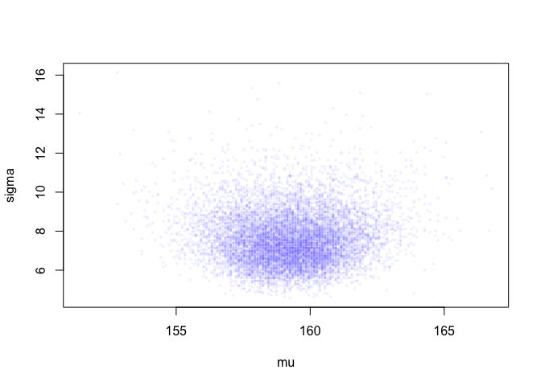

```r
## R code 4.23
d3 <- sample( d2$height , size=20 )

## R code 4.24
mu.list <- seq( from=150, to=170 , length.out=200 )
sigma.list <- seq( from=4 , to=20 , length.out=200 )
post2 <- expand.grid( mu=mu.list , sigma=sigma.list )
post2$LL <- sapply( 1:nrow(post2) , function(i)
    sum( dnorm( d3 , mean=post2$mu[i] , sd=post2$sigma[i] ,
    log=TRUE ) ) )
post2$prod <- post2$LL + dnorm( post2$mu , 178 , 20 , TRUE ) +
    dunif( post2$sigma , 0 , 50 , TRUE )
post2$prob <- exp( post2$prod - max(post2$prod) )
sample2.rows <- sample( 1:nrow(post2) , size=1e4 , replace=TRUE ,
    prob=post2$prob )
sample2.mu <- post2$mu[ sample2.rows ]
sample2.sigma <- post2$sigma[ sample2.rows ]
plot( sample2.mu , sample2.sigma , cex=0.5 ,
    col=col.alpha(rangi2,0.1) ,
    xlab="mu" , ylab="sigma" , pch=16 )
```

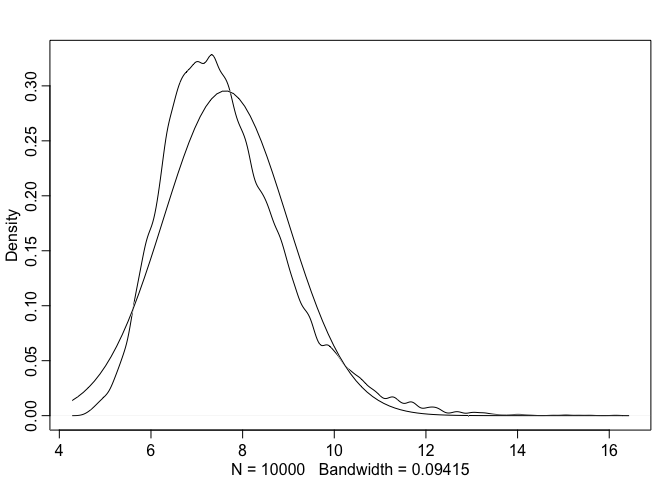

```r
## R code 4.25
dens( sample2.sigma , norm.comp=TRUE )
```

4.3.5. Finding the posterior distribution with quap. Quadratic approximation

```r
## R code 4.26
library(rethinking)
data(Howell1)
d <- Howell1
d2 <- d[ d$age >= 18 , ]

## R code 4.27
flist <- alist(
    height ~ dnorm( mu , sigma ) ,
    mu ~ dnorm( 178 , 20 ),
    sigma ~ dunif(0, 50)
)

## R code 4.28
m4.1 <- quap( flist , data=d2 )

## R code 4.29
precis( m4.1 )
```

```
##             mean        sd       5.5%      94.5%
## mu    154.606999 0.4119923 153.948556 155.265443
## sigma   7.731288 0.2913818   7.265603   8.196972
```

Overthinking: Start values for quap.

```r
## R code 4.30
start <- list(
    mu=mean(d2$height),
    sigma=sd(d2$height)
)
m4.1 <- quap( flist , data=d2 )


## R code 4.31
m4.2 <- quap(
        alist(
            height ~ dnorm( mu , sigma ) ,
            mu ~ dnorm( 178 , 0.1 ) ,
            sigma ~ dunif( 0 , 50 )
        ) ,
        data=d2 )
precis( m4.2 )
```

```
##            mean        sd     5.5%     94.5%
## mu    177.86383 0.1002354 177.7036 178.02403
## sigma  24.52784 0.9298911  23.0417  26.01399
```

4.3.6. Sampling from a quap.

```r
### variance-covariance matrix.
## R code 4.30
vcov( m4.1 )
```

```
##                 mu        sigma
## mu    0.1697427879 0.0002201997
## sigma 0.0002201997 0.0849097829
```

```r
## R code 4.31
diag( vcov( m4.1 ) )
```

```
##         mu      sigma
## 0.16974279 0.08490978
```

```r
cov2cor( vcov( m4.1 ) )
```

```
##                mu       sigma
## mu    1.000000000 0.001834181
## sigma 0.001834181 1.000000000
```

```r
## R code 4.32
library(rethinking)
post <- extract.samples( m4.1 , n=1e4 )
head(post)
```

```
##         mu    sigma
## 1 154.0911 8.083421
## 2 154.7753 7.405807
## 3 154.3527 7.979133
## 4 154.2974 7.524490
## 5 154.4376 7.249325
## 6 153.9441 7.294935
```

```r
## R code 4.33
precis(post)
```

```
##             mean        sd       5.5%      94.5%    histogram
## mu    154.605603 0.4173108 153.944096 155.282411      ▁▁▅▇▂▁▁
## sigma   7.727041 0.2948802   7.258103   8.202516 ▁▁▁▂▅▇▇▃▁▁▁▁
```

Overthinking: Under the hood with multivariate sampling.

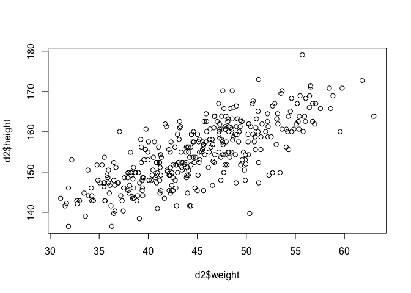

```r
## R code 4.34
library(MASS)
post <- mvrnorm( n=1e4 , mu=coef(m4.1) , Sigma=vcov(m4.1) )
## R code 4.37
plot( d2$height ~ d2$weight )
```

4.4. Adding a predictor

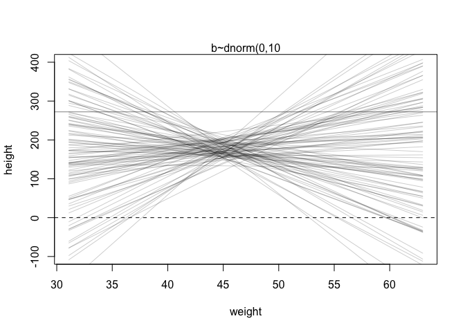

```r
## R code 4.38
set.seed(2971)
N <- 100 #100 lines
a <- rnorm(N,178,20)
b <- rnorm(N, 0, 10)
## R code 4.39 (Figure 4.5)
plot(NULL,xlim=range(d2$weight),ylim=c(-100,400),xlab="weight",ylab="height")
abline(h=0,lty=2)
abline(h=272,lty=1,lwd=0.5)
mtext("b~dnorm(0,10")
xbar <- mean(d2$weight)
for(i in 1:N) curve(a[i]+b[i]*(x - xbar),
                    from=min(d2$weight),to=max(d2$weight),add=TRUE,col=col.alpha("black",0.2))
```

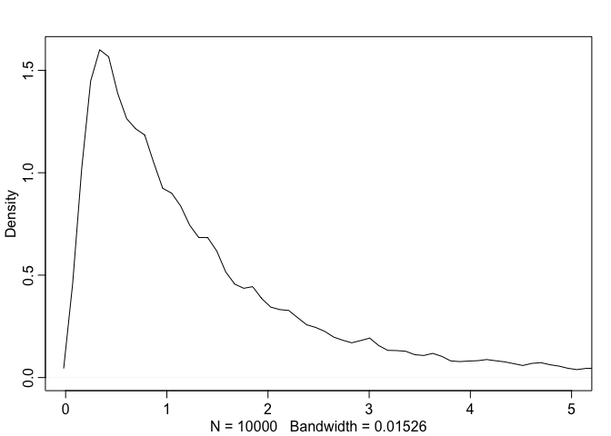

```r
## R code 4.40: Defining β as Log-Normal
b <- rlnorm(1e4,0,1)
dens(b,xlim=c(0,5),adj=0.1)
```

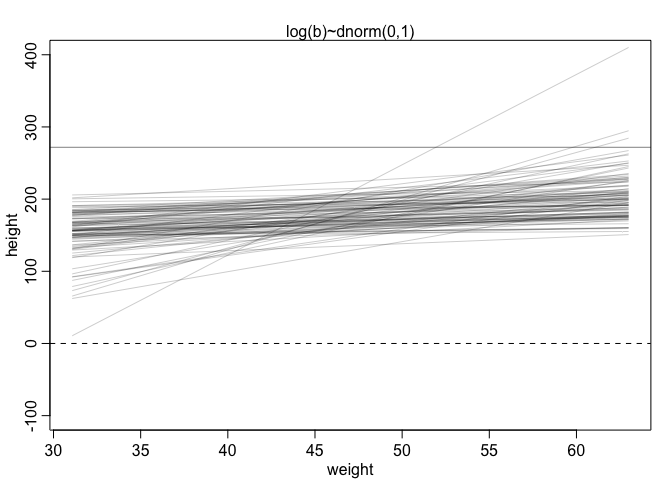

```r
## R code 4.41
set.seed(2971)
N <- 100 #100 lines
a <- rnorm(N,178,20)
b <- rlnorm(N, 0, 1) # changed
## my own
plot(NULL,xlim=range(d2$weight),ylim=c(-100,400),xlab="weight",ylab="height")
abline(h=0,lty=2)
abline(h=272,lty=1,lwd=0.5)
mtext("log(b)~dnorm(0,1)")
xbar <- mean(d2$weight)
for(i in 1:N) curve(a[i]+b[i]*(x - xbar),
                    from=min(d2$weight),to=max(d2$weight),add=TRUE,col=col.alpha("black",0.2))
```

```r
## R code 4.42
# load data again, since it's a long way back
library(rethinking)
data(Howell1)
d <- Howell1
d2 <- d[ d$age >= 18 , ]
# define the average weight, x-bar
xbar <- mean(d2$weight)

# fit model
m4.3 <- quap(
    alist(
        height ~ dnorm( mu , sigma ) ,
        mu <- a + b*(weight - xbar) ,
        a ~ dnorm( 178 , 20 ) ,
        b ~ dlnorm( 0 , 1 ) ,
        sigma ~ dunif( 0 , 50 )
    ) ,
    data=d2 )
```

## R code 4.43

- Overthinking: Logs and exps, oh my. The Log-Normal prior for β can be coded another way. Instead of defining a parameter β, we define a parameter that is the logarithm of β and then assign it a normal distribution. Then we can reverse the logarithm inside the linear model. It looks like this:

```r
m4.3b <- quap(
    alist(
        height ~ dnorm(mu , sigma ) ,
        mu <- a + exp(log_b)*(weight-xbar),
        a ~ dnorm( 178 , 100 ) ,
        b ~ dnorm( 0 , 10 ) ,
        log_b ~ dnorm( 0 , 1 ),
        sigma~dunif(0,50)
    ) ,
    data=d2 )
```

4.4.3. Interpreting the posterior distribution. 4.4.3.1. Tables of marginal distributions

```r
## R code 4.44
precis( m4.3 )
```

```
##              mean         sd        5.5%       94.5%
## a     154.6013671 0.27030766 154.1693633 155.0333710
## b       0.9032807 0.04192363   0.8362787   0.9702828
## sigma   5.0718809 0.19115478   4.7663786   5.3773831
```

```r
# Remember, the numbers in the default precis output aren’t sufficient to describe the quadratic posterior completely. For that, we also require the variance-covariance matrix. You can see the covariances among the parameters with vcov:
## R code 4.45
round(vcov(m4.3),3)
```

```
##           a     b sigma
## a     0.073 0.000 0.000
## b     0.000 0.002 0.000
## sigma 0.000 0.000 0.037
```

```r
# Very little covariation among the parameters in this case. Using pairs(m4.3) shows both the marginal posteriors and the covariance. In the problems at the end of the chapter, you’ll see that the lack of covariance among the parameters results from the something called cen- tering.
```

4.4.3.2. Plotting posterior inference against the data.

```r
# We’re going to start with a simple version of that task, superimposing just the posterior mean values over the height and weight data. Then we’ll slowly add more and more infor- mation to the prediction plots, until we’ve used the entire posterior distribution. We’ll start with just the raw data and a single line. The code below plots the raw data, computes the posterior mean values for a and b, then draws the implied line:

## R code 4.46
4.46
```

```
## [1] 4.46
```

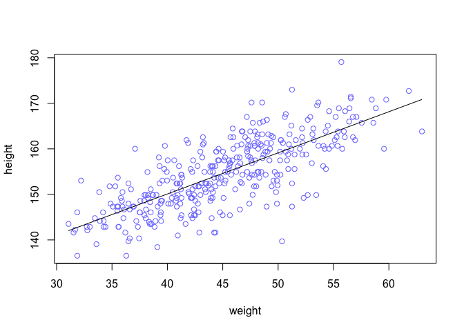

```r
plot( height ~ weight , data=d2 , col=rangi2 )
post <- extract.samples( m4.3 )
a_map <- mean(post$a)
b_map <- mean(post$b)
curve( a_map + b_map*(x - xbar) , add=TRUE )
```

4.4.3.3. Adding uncertainty around the mean.

```r
# To better appreciate how the posterior distribution contains lines, we work with all of the samples from the model. Let’s take a closer look at the samples now:
post <- extract.samples( m4.3 )
post[1:5,]
```

```
##          a         b    sigma
## 1 154.9493 0.9075067 4.873812
## 2 154.8834 0.9578025 5.120553
## 3 154.4967 0.8987900 5.161813
## 4 154.2916 0.8414611 4.755758
## 5 154.5858 0.9608629 5.125150
```

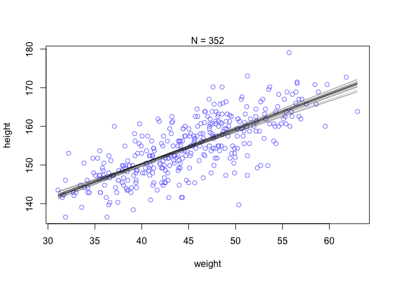

```r
# Each row is a correlated random sample from the joint posterior of all three parameters, using the covariances provided by vcov(m4.3). The paired values of a and b on each row define a line. The average of very many of these lines is the posterior mean line. But the scatter around that average is meaningful, because it alters our confidence in the relationship between the predictor and the outcome.

## R code 4.48
N <- 352
dN <- d2[ 1:N , ]
mN <- quap(
    alist(
        height ~ dnorm( mu , sigma ) ,
        mu <- a + b*(weight -mean(weight)),
        a ~ dnorm( 178 , 20 ) ,
        b ~ dlnorm( 0 , 1 ) ,
        sigma ~ dunif( 0 , 50 )
    ) , data=dN )

## R code 4.49
# extract 20 samples from the posterior
post <- extract.samples( mN , n=20 )

# display raw data and sample size
plot( dN$weight , dN$height ,
    xlim=range(d2$weight) , ylim=range(d2$height) ,
    col=rangi2 , xlab="weight" , ylab="height" )
mtext(concat("N = ",N))

# plot the lines, with transparency
for ( i in 1:20 )
    curve(post$a[i] + post$b[i]*(x-mean(dN$weight)) , col=col.alpha("black",0.3),add=TRUE) # d2 has 352
```

4.4.3.4 Plotting regression intervals nd contours.

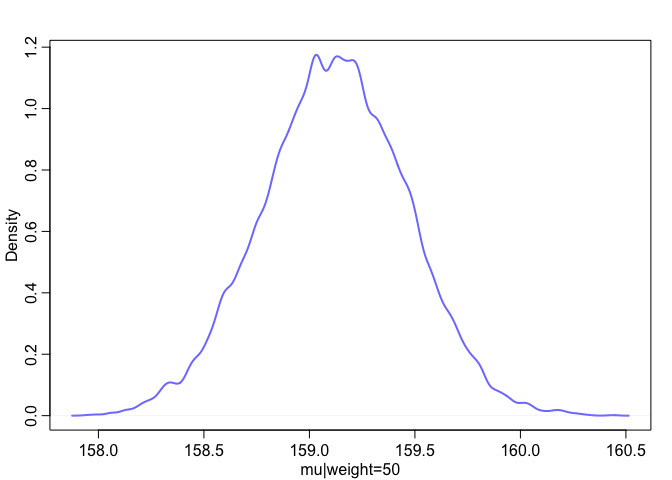

```r
## R code 4.50
post <- extract.samples(m4.3)
mu_at_50 <- post$a + post$b * (50-xbar)

## R code 4.51
dens( mu_at_50 , col=rangi2 , lwd=2 , xlab="mu|weight=50" )
```

```r
## R code 4.52
HPDI( mu_at_50 , prob=0.89 )
```

```
##    |0.89    0.89|
## 158.5710 159.6676
```

```r
# That’s good so far, but we need to repeat the above calculation for every weight value on the horizontal axis, not just when it is 50 kg. We want to draw 89% HPDIs around the average slope in Figure 4.6.

# This is made simple by strategic use of the link function, a part of the rethinking package.
## R code 4.53
mu <- link( m4.3 )
str(mu)
```

```
##  num [1:1000, 1:352] 158 157 157 157 157 ...
```

```r
## R code 4.54
# define sequence of weights to compute predictions for
# these values will be on the horizontal axis
weight.seq <- seq( from=25 , to=70 , by=1 )

# use link to compute mu
# for each sample from posterior
# and for each weight in weight.seq
mu <- link( m4.3 , data=data.frame(weight=weight.seq) )
str(mu)
```

```
##  num [1:1000, 1:46] 136 136 137 136 137 ...
```

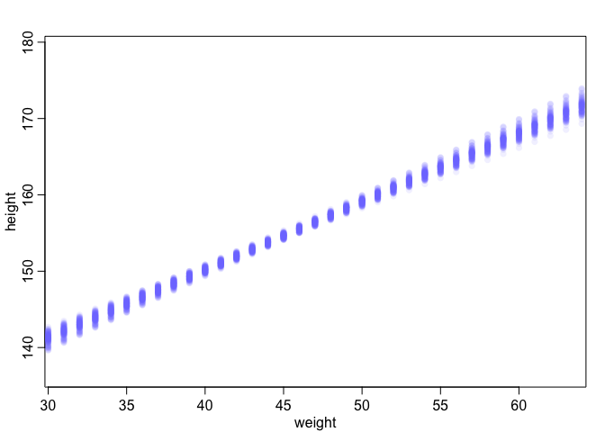

```r
## R code 4.55
# use type="n" to hide raw data
plot( height ~ weight , d2 , type="n" )

# loop over samples and plot each mu value
for ( i in 1:100 )
    points( weight.seq , mu[i,] , pch=16 , col=col.alpha(rangi2,0.1) ) # Fig 4.9
```

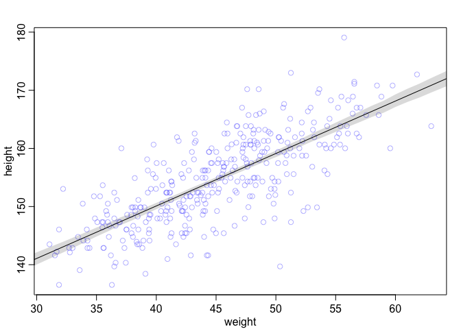

```r
## R code 4.56
# summarize the distribution of mu
mu.mean <- apply( mu , 2 , mean )
mu.HPDI <- apply( mu , 2 , HPDI , prob=0.89 )

## R code 4.57
# plot raw data
# fading out points to make line and interval more visible
plot( height ~ weight , data=d2 , col=col.alpha(rangi2,0.5) )

# plot the MAP line, aka the mean mu for each weight
lines( weight.seq , mu.mean )

# plot a shaded region for 89% HPDI
shade( mu.HPDI , weight.seq )
```

```r
## R code 4.58
post <- extract.samples(m4.3)
mu.link <- function(weight) post$a + post$b*weight
weight.seq <- seq( from=25 , to=70 , by=1 )
mu <- sapply( weight.seq , mu.link )
mu.mean <- apply( mu , 2 , mean )
mu.HPDI <- apply( mu , 2 , HPDI , prob=0.89 )
```

4.4.3.5. Prediction intervals.

```r
## R code 4.59
sim.height <- sim( m4.3 , data=list(weight=weight.seq) )
str(sim.height)
```

```
##  num [1:1000, 1:46] 133 141 141 140 130 ...
```

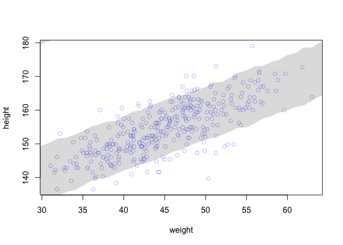

```r
## R code 4.60
height.PI <- apply( sim.height , 2 , PI , prob=0.89 )
# Let’s plot everything we’ve built up: (1) the average line, (2) the shaded region of 89% plausible μ, and (3) the boundaries of the simulated heights the model expects.(Fig 4.10)
## R code 4.61
# plot raw data
plot( height ~ weight , d2 , col=col.alpha(rangi2,0.5) )

# draw MAP line
lines( weight.seq , mu.mean )

# draw HPDI region for line
shade( mu.HPDI , weight.seq )

# draw PI region for simulated heights
shade( height.PI , weight.seq )
```

```r
## R code 4.62
sim.height <- sim( m4.3 , data=list(weight=weight.seq) , n=1e4 )
height.PI <- apply( sim.height , 2 , PI , prob=0.89 )
```

Overthinking: Rolling your own sim. ## R code 4.63 # Just like with link, it’s useful to know a little about how sim operates. For every distribution like dnorm, there is a companion simulation function. For the Gaussian distribution, the companion is rnorm, and it simulates sampling from a Gaussian distribu- tion. What we want R to do is simulate a height for each set of samples, and to do this for each value of weight. The following will do it

```r
post <- extract.samples(m4.3)
weight.seq <- 25:70
sim.height <- sapply( weight.seq , function(weight)
    rnorm(
        n=nrow(post) ,
        mean=post$a + post$b*weight ,
        sd=post$sigma ) )
height.PI <- apply( sim.height , 2 , PI , prob=0.89 )
```

4.5. Curves from lines 4.5.1 Polynomial regression

```r
## R code 4.64
library(rethinking)
data(Howell1)
d <- Howell1
str(d)
```

```
## 'data.frame':    544 obs. of  4 variables:
##  $ height: num  152 140 137 157 145 ...
##  $ weight: num  47.8 36.5 31.9 53 41.3 ...
##  $ age   : num  63 63 65 41 51 35 32 27 19 54 ...
##  $ male  : int  1 0 0 1 0 1 0 1 0 1 ...
```

```r
## R code 4.65
d$weight.s <- ( d$weight - mean(d$weight) )/sd(d$weight)
d$weight.s2 <- d$weight.s^2
m4.5 <- quap(
    alist(
        height ~ dnorm( mu , sigma ) ,
        mu <- a + b1*weight.s + b2*weight.s2 ,
        a ~ dnorm( 178 , 20 ) ,
        b1 ~ dlnorm( 0 , 1 ) ,
        b2 ~ dnorm( 0 , 1 ) ,
        sigma ~ dunif( 0 , 50 )
    ) ,
    data=d )

## R code 4.66
precis( m4.5 )
```

```
##             mean        sd       5.5%      94.5%
## a     146.058396 0.3689817 145.468692 146.648100
## b1     21.732482 0.2888959  21.270771  22.194194
## b2     -7.804507 0.2741831  -8.242704  -7.366309
## sigma   5.774656 0.1764780   5.492610   6.056702
```

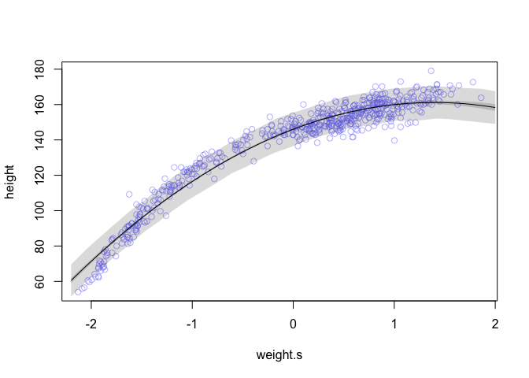

```r
# You have to plot these model fits to understand what they are saying. So let’s do that. We’ll calculate the mean relationship and the 89% intervals of the mean and the predictions, like in the previous section.
## R code 4.67
weight.seq <- seq( from=-2.2 , to=2 , length.out=30 )
pred_dat <- list( weight.s=weight.seq , weight.s2=weight.seq^2 )
mu <- link( m4.5 , data=pred_dat )
mu.mean <- apply( mu , 2 , mean )
mu.PI <- apply( mu , 2 , PI , prob=0.89 )
sim.height <- sim( m4.5 , data=pred_dat )
height.PI <- apply( sim.height , 2 , PI , prob=0.89 )

## R code 4.68
plot( height ~ weight.s , d , col=col.alpha(rangi2,0.5) )
lines( weight.seq , mu.mean )
shade( mu.PI , weight.seq )
shade( height.PI , weight.seq )
```

a higher-order polynomial regression, a cubic regression on weight.

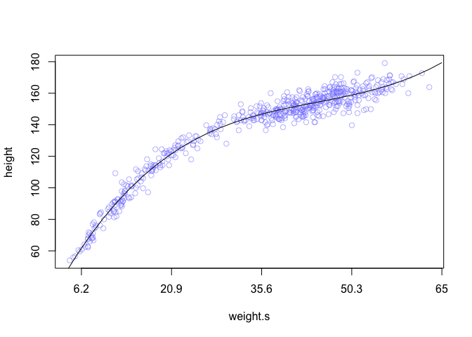

```r
## R code 4.70
d$weight.s3 <- d$weight.s^3
m4.6 <- quap(
    alist(
        height ~ dnorm( mu , sigma ) ,
        mu <- a + b1*weight.s + b2*weight.s2 + b3*weight.s3 ,
        a ~ dnorm( 178 , 20 ) ,
        b1 ~ dlnorm( 0 , 1 ) ,
        b2 ~ dnorm( 0 , 10 ) ,
        b3 ~ dnorm( 0 , 10 ) ,
        sigma ~ dunif( 0 , 50 )
    ) ,
    data=d )

## R code 4.71
plot( height ~ weight.s , d , col=col.alpha(rangi2,0.5) , xaxt="n" )

## R code 4.71
at <- c(-2,-1,0,1,2)
labels <- at*sd(d$weight) + mean(d$weight)
axis( side=1 , at=at , labels=round(labels,1) )
## adding following codes by KN
pred_dat <- list( weight.s=weight.seq , weight.s2=weight.seq^2, weight.s3=weight.seq^3)
mu <- link(m4.6 , data=pred_dat )
mu.mean <- apply( mu , 2 , mean )
lines( weight.seq , mu.mean )
```

```r
# Let’s load a thousand years of Japanese cherry blossom dates
## R code 4.72
library(rethinking)
data(cherry_blossoms)
d<-cherry_blossoms
precis(d)
```

```
##                   mean          sd      5.5%      94.5%       histogram
## year       1408.000000 350.8845964 867.77000 1948.23000   ▇▇▇▇▇▇▇▇▇▇▇▇▁
## doy         104.540508   6.4070362  94.43000  115.00000        ▁▂▅▇▇▃▁▁
## temp          6.141886   0.6636479   5.15000    7.29470        ▁▃▅▇▃▂▁▁
## temp_upper    7.185151   0.9929206   5.89765    8.90235 ▁▂▅▇▇▅▂▂▁▁▁▁▁▁▁
## temp_lower    5.098941   0.8503496   3.78765    6.37000 ▁▁▁▁▁▁▁▃▅▇▃▂▁▁▁
```

```r
## R code 4.73
d2 <- d[ complete.cases(d$temp) , ] # complete cases on temp
num_knots <- 15
knot_list <- quantile( d2$year , probs=seq(0,1,length.out=num_knots) ) # Go ahead and inspect knot_list to see that it contains 15 evenly spaced dates, covering the full range of the data.
```

# The next choice is polynomial degree.

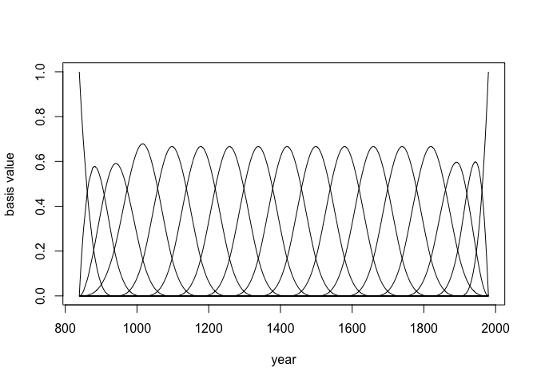

```r
## R code 4.74
library(splines)
# function bs "Generate the B-spline basis matrix for a polynomial spline."
B <- bs(d2$year,
    knots=knot_list[-c(1,num_knots)] ,
    degree=3 , intercept=TRUE ) # play with degree and check dim(B)
# The matrix B should have 1124 rows and 17 columns. Each row is a year, corresponding to the rows in the d2 data frame.
# R code 4.75 (plot B matrix)
plot( NULL , xlim=range(d2$year) , ylim=c(0,1) , xlab="year" , ylab="basis value" )
for ( i in 1:ncol(B) ) lines( d2$year , B[,i] )
```

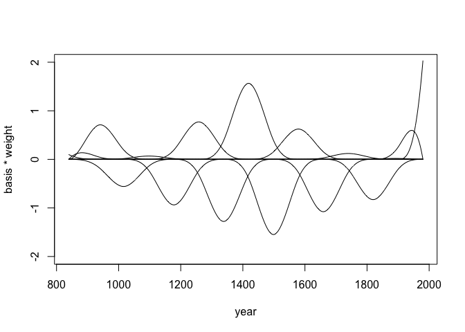

```r
# R code 4.76 (modeling)
m4.7 <- quap(
    alist(
        T ~ dnorm( mu , sigma ) ,
        mu <- a + B %*% w ,
        a ~ dnorm(6,10),
        w ~ dnorm(0,1),
        sigma ~ dexp(1)
    ),
    data=list( T=d2$temp , B=B ) ,
    start=list( w=rep( 0 , ncol(B) ) ) )

# R code 4.77
post <- extract.samples(m4.7)
w <- apply( post$w , 2 , mean )
plot( NULL , xlim=range(d2$year) , ylim=c(-2,2) ,
    xlab="year" , ylab="basis * weight" )
for ( i in 1:ncol(B) ) lines( d2$year , w[i]*B[,i] )
```

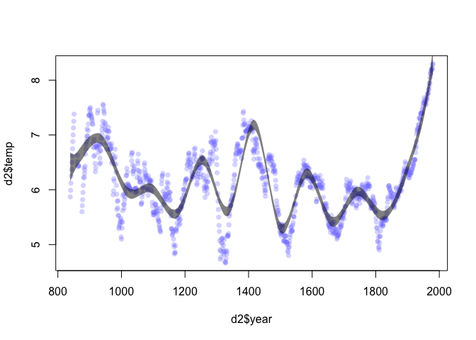

```r
# R code 4.78
#This plot, with the knots added for reference, is displayed in the middle row of Figure 4.13. And finally the 97% posterior interval for μ, at each year:
mu <- link( m4.7 )
mu_PI <- apply(mu,2,PI,0.97)
plot( d2$year , d2$temp , col=col.alpha(rangi2,0.3) , pch=16 )
shade( mu_PI , d2$year , col=col.alpha("black",0.5) )
```

4.7. Practice # 4E1. (A) yi

# 4E2. (A) 2 (mu and sigma)

# 4E3. (Q) Using the model definition above, write down the appropriate form of Bayes’ theorem that includes the proper likelihood and priors.

# 4E4 (A) 2nd line (mu i = …)

# 4E5 three (alpha, beta, sigma)

# 4M1 For the model definition below, simulate observed heights from the prior (not the posterior).

yi ∼ Normal(μ, σ) μ ∼ Normal(0, 10) σ ∼ Uniform(0, 10)

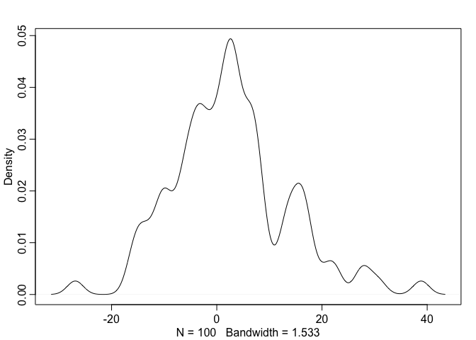

```r
sample_mu <- rnorm(1e2,0,10)
sample_sigma <- runif(1e2,0,10)
prior_y<-rnorm(1e2,sample_mu,sample_sigma)
dens(prior_y)
```

# 4M2. Translate the model just above into a quap formula.

```r
list.4M2 <- alist(
    yi ~ dnorm(mu , sigma) ,
    mu ~ dnorm(0 , 10 ),
    sigma ~ dunif(0, 10)
)
m.4M2 <- quap(list.4M2 , data=data.frame(yi=prior_y))
```

```
## Error in quap(list.4M2, data = data.frame(yi = prior_y)): non-finite finite-difference value [2]
## Start values for parameters may be too far from MAP.
## Try better priors or use explicit start values.
## If you sampled random start values, just trying again may work.
## Start values used in this attempt:
## mu = -8.05219733918305
## sigma = 5.67413844866678
```

```r
m.4M2 <- quap(list.4M2 , data=data.frame(yi=prior_y),start=list(mu=0,sigma=0.1))
```

```
## Error in quap(list.4M2, data = data.frame(yi = prior_y), start = list(mu = 0, : non-finite finite-difference value [2]
## Start values for parameters may be too far from MAP.
## Try better priors or use explicit start values.
## If you sampled random start values, just trying again may work.
## Start values used in this attempt:
## mu = 0
## sigma = 0.1
```

```r
yi<-d2$height
m.4M2 <- quap(list.4M2 , data=data.frame(yi))
```

```
## Error in quap(list.4M2, data = data.frame(yi)): Non-numeric argument to mathematical function
```

```r
#
d3<-data.frame(yi=prior_y)
m.4M2 <- quap(list.4M2 , data=d3,start=list(mu=0,sigma=0.1))
```

```
## Error in quap(list.4M2, data = d3, start = list(mu = 0, sigma = 0.1)): non-finite finite-difference value [2]
## Start values for parameters may be too far from MAP.
## Try better priors or use explicit start values.
## If you sampled random start values, just trying again may work.
## Start values used in this attempt:
## mu = 0
## sigma = 0.1
```

```r
#
d4<-data.frame(yi=prior_y+abs(min(prior_y)))
d4
```

[output not shown]

[output cut: 86 more lines]

```r
m.4M2 <- quap(list.4M2 , data=d4)
```

```
## Error in quap(list.4M2, data = d4): non-finite finite-difference value [2]
## Start values for parameters may be too far from MAP.
## Try better priors or use explicit start values.
## If you sampled random start values, just trying again may work.
## Start values used in this attempt:
## mu = 9.62993423104081
## sigma = 4.57467656815425
```

```r
# errors!
precis( m.4M2 )
```

```
## Error in precis(m.4M2): object 'm.4M2' not found
```

```r
#
list.4M2.b <- alist(
    yi ~ dnorm(mu , sigma) ,
    mu ~ dnorm(0 , 10 ),
    sigma ~ dunif(0, 15)
) # simulated data prior_y has larger sigma than 10, so giving zero in sigma in thi prior. Change sigma to duni(0,15) should work
m.4M2.b <- quap(list.4M2.b , data=data.frame(yi=prior_y)) #?
precis( prior_y )
```

```
##             mean       sd      5.5%    94.5%      histogram
## prior_y 2.608663 11.06402 -13.33111 21.16978 ▁▁▁▂▃▅▇▅▂▂▁▁▁▁
```

```r
precis(m.4M2.b)
```

```
##            mean        sd      5.5%    94.5%
## mu     2.577404 1.0942579 0.8285686  4.32624
## sigma 11.008598 0.7784304 9.7645160 12.25268
```

# 4M3

Translate the quap model formula below into a mathematical model definition. ## see Juli’s code for mathematical equation in Rmarkdown

```r
flist <- alist(
    y ~ dnorm( mu , sigma ),
    mu <- a + b*x,
    a ~ dnorm( 0 , 50 ),
    b ~ dunif( 0 , 10 ),
    sigma ~ dunif( 0 , 50 )
)
```

Answer

Yi ~ Normal(mu,sigma)

alpha ~ Normal(0,50)

beta ~ Uniform(0,10)

sigma ~ Uniform(0,50)

# 4M4 A sample of students is measured for height each year for 3 years.After the third year,you want to fit a linear regression predicting height using year as a predictor. Write down the mathematical model definition for this regression, using any variable names and priors you choose. Be prepared to defend your choice of priors.

## (Note) Check how to write equation below in Julin’s code

```r
Hight.i~Normal(mu.i,sigma)
mu.i ~ alpha + beta*(year.i-year.first)
alpha ~ Normal(Hight.prior,alpha.prior) # Hight.prior, 1st year average height calculated from prior;alpha.prior is calculated from three year data
beta ~Normal(beta.prior,1)
# Log Normal is better
beta ~ Log-Norm()
# waht number?
betas <- seq(0,20,by=1)
plot(betas,dlnorm(betas,2.3,1),type="l")
#
sigma~Uniform(0,50) # why???
```

# 4M5. Now suppose I tell you that the average height in the first year was 120 cm and that every student got taller each year. Does this information lead you to change your choice of priors? How?

```r
# Hight.prior = 120 cm
# beta >0
```

# 4M6. Now suppose I tell you that the variance among heights for students of the same age is never more than 64cm. How does this lead you to revise your priors?

```r
sigma~Uniform(0,64) # sigma is variance, so should be 8!
```

```
## sigma ~ Uniform(0, 64)
```

# 4H1. The weights listed be low were recorded in the !Kung census,but heights were not recorded for these individuals. Provide predicted heights and 89% intervals (either HPDI or PI) for each of these individuals. That is, fill in the table below, using model-based predictions.

```r
data.4H1<-data.frame(weight=c(46.95,43.72,64.78,32.59,54.63))
# # Does not work. Needs height data.
# data.4H1<-data.frame(weight=c(46.95,43.72,64.78,32.59,54.63),height="")
# data.4H1$height<-1.5*data.4H1$weight + 30 # assumption (prior)

library(rethinking)
data(Howell1) #
d <- Howell1
#,expected_height="",eightynine_percent_interval="")
#xbar<-mean(d$weight)

list.4H1 <- alist(
    height ~ dnorm( mu , sigma ),
    mu<- a + b*weight,
        a ~ dnorm( 178 , 20 ) ,
        b ~ dlnorm( 0 , 1 ) ,
    sigma ~ dunif( 0 , 30 )
)
m4H1<-quap(list.4H1 , data=d) #
precis(m4H1)
```

```
##            mean         sd      5.5%     94.5%
## a     75.741257 1.04866516 74.065288 77.417227
## b      1.756875 0.02722379  1.713366  1.800384
## sigma  9.346608 0.28340459  8.893673  9.799544
```

```r
#extract.samples(m4H1)
# modified from R code 4.58
post <- extract.samples(m4H1)
mu.link <- function(weight) post$a + post$b*weight
#weight.seq <- seq( from=25 , to=70 , by=1 )
mu <- sapply( data.4H1$weight , mu.link )
data.4H1$expected.height<-mu.mean <- apply( mu , 2 , mean )
data.4H1$HPDI.5.5<-mu.HPDI <- apply( mu , 2 , HPDI , prob=0.89 )[1,]
data.4H1$HPDI.94.5<-mu.HPDI <- apply( mu , 2 , HPDI , prob=0.89 )[2,]
data.4H1 # what? somthing wrong?
```

```
##   weight expected.height HPDI.5.5 HPDI.94.5
## 1  46.95        158.2255 157.3834  158.9738
## 2  43.72        152.5498 151.8152  153.2517
## 3  64.78        189.5557 188.1655  190.9707
## 4  32.59        132.9926 132.3436  133.6417
## 5  54.63        171.7205 170.6729  172.7239
```

# 4H2. Select out all the rows in the Howell1 data with ages below 18 years of age. If you do it right, you should end up with a new data frame with 192 rows in it.

## (a) Fit a linear regression to these data, using quap. Present and interpret the estimates. For every 10 units of increase in weight, how much taller does the model predict a child gets?

## (b) Plot the raw data, with height on the vertical axis and weight on the horizontal axis. Super- impose the MAP regression line and 89% HPDI for the mean. Also superimpose the 89% HPDI for predicted heights.

## (c) What aspects of the model fit concern you? Describe the kinds of assumptions you would change, if any, to improve the model. You don’t have to write any new code. Just explain what the model appears to be doing a bad job of, and what you hypothesize would be a better model.